[figure not shown]

# Parcours Data Analyst

## Projet 9 : Prédisez la demande en électricité

### Thomas Dupouy - 11/2018

```r
setwd("/data/P9/")
library(dplyr) # très utile
library(reshape2) # dcast, melt
library(ggfortify) # autoplot
library(xts) # Séries temporelles
library(lubridate) # le choix dans la date
library(forecast) # Acf, Pacf, ma
library(tseries) # adf.test
library(caschrono) # t_stat
options(repr.plot.width=12, repr.plot.height=3)
```

# Téléchargement des données

Vous téléchargerez les données de consommation d'électricité mensuelles à partir de cette page : http://www.rte-france.com/fr/eco2mix/eco2mix-telechargement

[figure not shown]

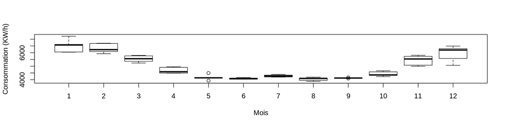

```r
# Lecture du fichier ECO2
ECO2 <- (read.csv("eco2mix-regional-cons-def.csv",sep=";",header=T)
        # Pour correspondre aux données DJU, on restreint la série sur une zone géographique
        %>% filter(Région=="Nouvelle-Aquitaine")
        # Seule les données dites définitives sont utilisées
        %>% filter(Nature=="Données définitives")
        %>% select(c(Date...Heure,Consommation..MW.))
        %>% na.omit
        %>% setNames(c("Date","Conso")))
# Conversion en série temporelle format xts
ECO2 <- (xts(ECO2$Conso,order.by=as.Date(ECO2$Date)) %>% apply.monthly(mean))
# Création d'un index base mensuelle
index(ECO2) <- floor_date(index(ECO2),"month")
# reconversion en timeserie
ECO2 <- ts(ECO2,frequency=12,start=c(2012, 12))
# et voilà!
boxplot(ECO2 ~ cycle(ECO2),xlab="Mois",ylab="Consommation (KW/h)")
```

Les données météo que vous utiliserez pour corriger les données de l'effet température sont présentes ici : https://cegibat.grdf.fr/simulateur/calcul-dju

Le **degré jour unifié** (DJU) est la différence entre la température extérieure et une température de référence

[figure not shown]

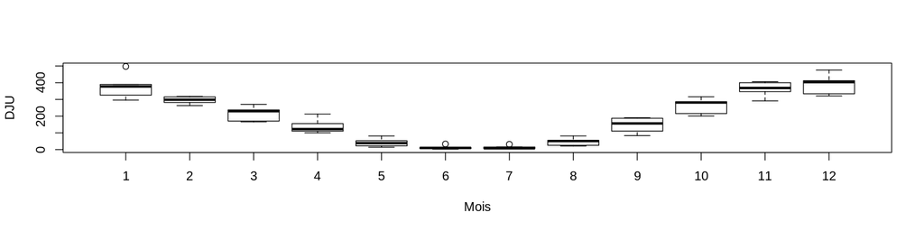

```r
# Le datasource CEGIBAT permet uniquement d'exporter des données géolocalisées
# Plutôt que de devoir créer un utilitaire de requêtage puis consolidation (hors sujet)
# on concentre l'étude sur la région Nouvelle-Aquitaine.
# Autre option : acheter les DJU mensuels nationaux à Météo-France
DJU <- (read.csv('Cegibat_DJU_17_10_2018.csv',sep=";",header=T)
        %>%  melt(id.vars = 'year')
        %>% filter(value>0))
# Création d'un index base mensuelle
idx <- floor_date(parse_date_time(paste(DJU$year,DJU$variable),"%Y %m"),"month")
# Conversion de la série en série temporelle format xts
DJU <- (xts(DJU$value,order.by=idx))
# reconversion en timeserie pour intégration avec Forecast
DJU <- ts(DJU,frequency=12,start=c(2012,12),end=c(2017,12))
# et voilà!
boxplot(DJU ~ cycle(DJU),xlab="Mois",ylab="DJU")
```

# Corrigez les données de consommation mensuelles de l'effet température (dues au chauffage électrique) en utilisant une régression linéaire.

| R2 | 0.59 |
| --- | --- |

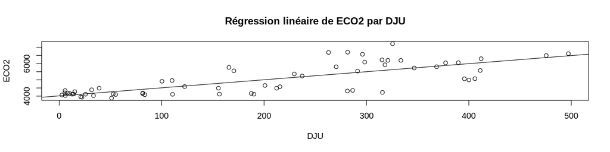

```r
# Regression linéaire des deux séries
# traitement particulier pour séries temporelles (c.f. doc lm)
base <- ts.intersect(ECO2, DJU, dframe=TRUE) %>% na.omit
res <- lm(base, na.action=NULL)

plot(as.numeric(DJU),as.numeric(ECO2),xlab="DJU",ylab="ECO2",main="Régression linéaire de ECO2 par DJU")
abline(res)
cbind("R2",round(summary(res)$r.squared,2))

# On soustrait les résidus à la série
res <- ts(residuals(res),frequency=12,start=c(2012,12))
ECO3 <- ECO2 - res

# Note : en pratique la régression linéaire n'est pas la méthode utilisée pour pondérer la consommation
# c.f. http://www.gpso-energie.fr/conseils/analyser-ses-consommations-dju
# Consommations corrigées = consommations x (DJU de référence/DJU de la période de consommation considérée)
```

## Consommation électrique corrigée de l'effet de température, de décembre 2012 à décembre 2017

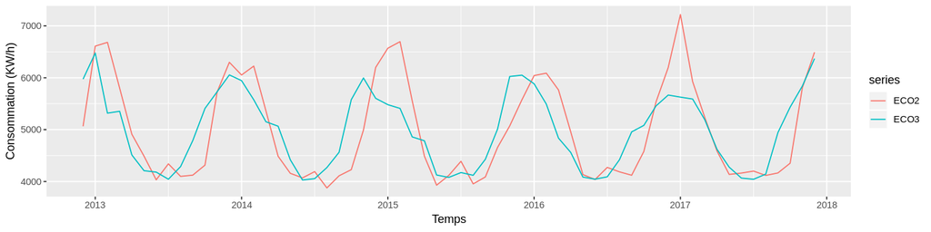

```r
autoplot(cbind(ECO2,ECO3),xlab="Temps",ylab="Consommation (KW/h)")
```

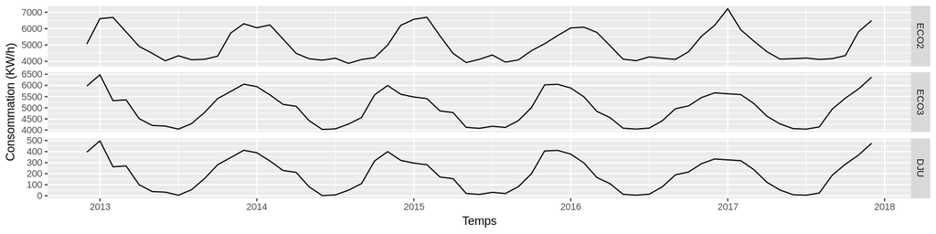

```r
autoplot(cbind(ECO2,ECO3,DJU),xlab="Temps",ylab="Consommation (KW/h)",facet=T)
```

# Effectuez une désaisonnalisation de la consommation que vous aurez obtenue après correction, grâce aux moyennes mobiles.

Décomposition de la série ECO3 en tendance, saisonnalité et résidus

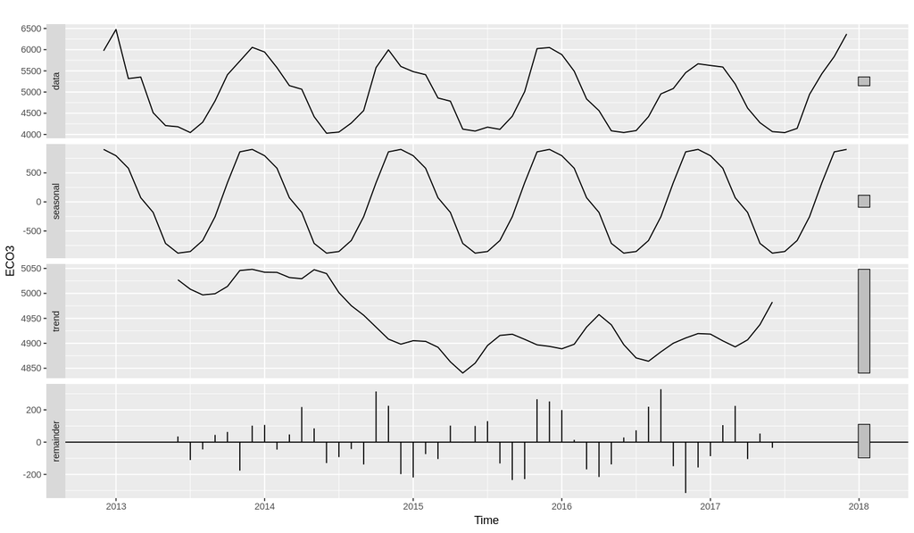

```r
options(repr.plot.height=7)
autoplot(decompose(ECO3),ylab="ECO3",main="")
options(repr.plot.height=3)
```